# Project 2: TMDb Movie Data Analysis

## Introduction

> In this project I'll be analysing the tmdb movie dataset, in my investigation, I will analyze how a movie's popularity differs over years, the most popular movies and some of the properties associated with movies of high revenues. The dataset contains information on 10000 movies from TMDb.

### Research Questions

> 1. Which genres are most popular from year to year?
> 2. Which genres is most popular ?
> 3. What kinds of properties are associated with movies that have high revenues ?

```python
#Import all required libraries
import pandas as pd
import numpy as np
import matplotlib.pyplot as plt
import seaborn as sns
# Added to enable our plots appear inside the notebook
%matplotlib inline
```

## Data Wrangling

> In this section of the report, I loaded the data and made it accessible from my workspace. During this process, I cleaned and restructured my dataset for analysis purposefully to help with easy analysis, better visualization and to arrive at an informed decision

### General Properties

```python
# Load and view the first 3 rows of the dataset
df = pd.read_csv('tmdb-movies.csv')
df.head(3)
```

|  | id | imdb_id | popularity | budget | revenue | original_title | cast | homepage | director | tagline | ... | overview | runtime | genres | production_companies | release_date | vote_count | vote_average | release_year | budget_adj | revenue_adj |
| --- | --- | --- | --- | --- | --- | --- | --- | --- | --- | --- | --- | --- | --- | --- | --- | --- | --- | --- | --- | --- | --- |
| 0 | 135397 | tt0369610 | 32.99 | 150000000 | 1513528810 | Jurassic World | Chris Pratt\|Bryce Dallas Howard\|Irrfan Khan\|Vi... | http://www.jurassicworld.com/ | Colin Trevorrow | The park is open. | ... | Twenty-two years after the events of Jurassic ... | 124 | Action\|Adventure\|Science Fiction\|Thriller | Universal Studios\|Amblin Entertainment\|Legenda... | 6/9/15 | 5562 | 6.50 | 2015 | 137999939.28 | 1392445892.52 |
| 1 | 76341 | tt1392190 | 28.42 | 150000000 | 378436354 | Mad Max: Fury Road | Tom Hardy\|Charlize Theron\|Hugh Keays-Byrne\|Nic... | http://www.madmaxmovie.com/ | George Miller | What a Lovely Day. | ... | An apocalyptic story set in the furthest reach... | 120 | Action\|Adventure\|Science Fiction\|Thriller | Village Roadshow Pictures\|Kennedy Miller Produ... | 5/13/15 | 6185 | 7.10 | 2015 | 137999939.28 | 348161292.49 |
| 2 | 262500 | tt2908446 | 13.11 | 110000000 | 295238201 | Insurgent | Shailene Woodley\|Theo James\|Kate Winslet\|Ansel... | http://www.thedivergentseries.movie/#insurgent | Robert Schwentke | One Choice Can Destroy You | ... | Beatrice Prior must confront her inner demons ... | 119 | Adventure\|Science Fiction\|Thriller | Summit Entertainment\|Mandeville Films\|Red Wago... | 3/18/15 | 2480 | 6.30 | 2015 | 101199955.47 | 271619025.41 |

3 rows × 21 columns

> In the above steps, I used pandas to read my CSV file and used the pandas head function to have a close look at the loaded CSV file

### Data sample

```python
# View a sample of the data in the dataset
df.sample(10)
```

[output not shown]

### Shape

```python
#Determine the number of rows and columns in the dataset
df.shape
```

```
(10866, 21)
```

> The shape function returned the number of rows and columns as a tuple

### Descriptive Statistics

```python
# Check for a quick descriptive summary of the dataset
df.describe()
```

|  | id | popularity | budget | revenue | runtime | vote_count | vote_average | release_year | budget_adj | revenue_adj |
| --- | --- | --- | --- | --- | --- | --- | --- | --- | --- | --- |
| count | 10866.00 | 10866.00 | 10866.00 | 10866.00 | 10866.00 | 10866.00 | 10866.00 | 10866.00 | 10866.00 | 10866.00 |
| mean | 66064.18 | 0.65 | 14625701.09 | 39823319.79 | 102.07 | 217.39 | 5.97 | 2001.32 | 17551039.82 | 51364363.25 |
| std | 92130.14 | 1.00 | 30913213.83 | 117003486.58 | 31.38 | 575.62 | 0.94 | 12.81 | 34306155.72 | 144632485.04 |
| min | 5.00 | 0.00 | 0.00 | 0.00 | 0.00 | 10.00 | 1.50 | 1960.00 | 0.00 | 0.00 |
| 25% | 10596.25 | 0.21 | 0.00 | 0.00 | 90.00 | 17.00 | 5.40 | 1995.00 | 0.00 | 0.00 |
| 50% | 20669.00 | 0.38 | 0.00 | 0.00 | 99.00 | 38.00 | 6.00 | 2006.00 | 0.00 | 0.00 |
| 75% | 75610.00 | 0.71 | 15000000.00 | 24000000.00 | 111.00 | 145.75 | 6.60 | 2011.00 | 20853251.08 | 33697095.72 |
| max | 417859.00 | 32.99 | 425000000.00 | 2781505847.00 | 900.00 | 9767.00 | 9.20 | 2015.00 | 425000000.00 | 2827123750.41 |

> Using the describe function, I obtained a few statistics that gave me some perspective on the nature of the data.

### Data Types

```python
# Check for each columns data type
df.dtypes
```

[output not shown]

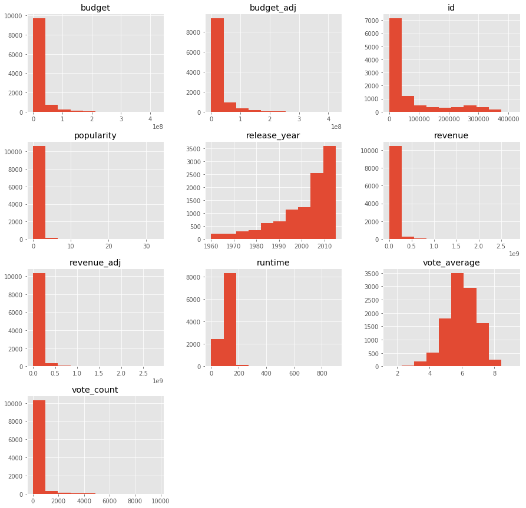

```python
# quick summarised visualization of the columns with numerics
df.hist(figsize=(15,15));
```

> The hist method provided me with a quick summarised visualization of the columns with numerics

### Deleting Unwanted Columns

To make my analysis more comfy and fast, I deleted some columns that I viewed as unnecessary for analysis as follows

```python
# Drop all the rows that will not be required during analysis
df.drop(['id','imdb_id','cast','homepage','tagline','overview','production_companies','release_date'],axis=1,inplace=True)
# Drop an extra column
df.drop('keywords',axis=1,inplace=True)
```

### Checking for duplicates

```python
# Count all the duplicated columns
sum(df.duplicated())
```

```
1
```

### Dropping Duplicates

```python
# Drop these duplicate columns in order
df.drop_duplicates(inplace=True)
```

### Dealing with Columns with Multiple Values

> Columns with multiple values make it cumbersome to visualize and understand our datasets, to make analysis easier I restructured the multiple-valued columns as shown below

```python
# Drop the column genres,then split the cell values to form new rows and rename as genres
df =(df.drop('genres',axis=1)
     .join(df['genres'].str.split('|',expand=True)
     .stack().reset_index(level=1,drop=True)
     .rename('genres'))
     .loc[:,df.columns])
```

```python
# Confirm changes
df.head()
```

|  | popularity | budget | revenue | original_title | director | runtime | genres | vote_count | vote_average | release_year | budget_adj | revenue_adj |
| --- | --- | --- | --- | --- | --- | --- | --- | --- | --- | --- | --- | --- |
| 0 | 32.99 | 150000000 | 1513528810 | Jurassic World | Colin Trevorrow | 124 | Action | 5562 | 6.50 | 2015 | 137999939.28 | 1392445892.52 |
| 0 | 32.99 | 150000000 | 1513528810 | Jurassic World | Colin Trevorrow | 124 | Adventure | 5562 | 6.50 | 2015 | 137999939.28 | 1392445892.52 |
| 0 | 32.99 | 150000000 | 1513528810 | Jurassic World | Colin Trevorrow | 124 | Science Fiction | 5562 | 6.50 | 2015 | 137999939.28 | 1392445892.52 |
| 0 | 32.99 | 150000000 | 1513528810 | Jurassic World | Colin Trevorrow | 124 | Thriller | 5562 | 6.50 | 2015 | 137999939.28 | 1392445892.52 |
| 1 | 28.42 | 150000000 | 378436354 | Mad Max: Fury Road | George Miller | 120 | Action | 6185 | 7.10 | 2015 | 137999939.28 | 348161292.49 |

### Checking for Columns with Null Values

```python
# Check the sum of null values in a column and then sort in a descending order
df.isnull().sum().sort_values(ascending = False).head(15)
```

```
director          93
genres            23
revenue_adj        0
budget_adj         0
release_year       0
vote_average       0
vote_count         0
runtime            0
original_title     0
revenue            0
budget             0
popularity         0
dtype: int64
```

### Dropping Null Values from columns

```python
# Let's drop all this null values
df.dropna(subset=['director','genres'], inplace=True)
```

> Since count specifically counts non-null values, the null values are dropped as they are not used in the subsequent steps.

```python
# confirm if changes were effective
df.isnull().sum().sort_values(ascending = False).head(15)
```

```
revenue_adj       0
budget_adj        0
release_year      0
vote_average      0
vote_count        0
genres            0
runtime           0
director          0
original_title    0
revenue           0
budget            0
popularity        0
dtype: int64
```

> All null values confirmed dropped

### Dealing with unusual values

```python
#Turn off scientific notation in pandas
pd.set_option('display.float_format',lambda x: '%.2f' % x)
```

```python
df.describe()
```

|  | popularity | budget | revenue | runtime | vote_count | vote_average | release_year | budget_adj | revenue_adj |
| --- | --- | --- | --- | --- | --- | --- | --- | --- | --- |
| count | 26864.00 | 26864.00 | 26864.00 | 26864.00 | 26864.00 | 26864.00 | 26864.00 | 26864.00 | 26864.00 |
| mean | 0.71 | 17565570.56 | 47602720.06 | 102.84 | 250.78 | 5.95 | 2000.68 | 21109198.50 | 61094461.08 |
| std | 1.12 | 34653162.06 | 132405415.73 | 29.80 | 638.96 | 0.91 | 12.77 | 38246054.65 | 161765454.21 |
| min | 0.00 | 0.00 | 0.00 | 0.00 | 10.00 | 1.50 | 1960.00 | 0.00 | 0.00 |
| 25% | 0.23 | 0.00 | 0.00 | 90.00 | 18.00 | 5.40 | 1994.00 | 0.00 | 0.00 |
| 50% | 0.41 | 5000.00 | 0.00 | 100.00 | 44.00 | 6.00 | 2005.00 | 5041.00 | 0.00 |
| 75% | 0.78 | 20000000.00 | 30925690.00 | 112.00 | 174.00 | 6.60 | 2011.00 | 27143145.19 | 44028788.73 |
| max | 32.99 | 425000000.00 | 2781505847.00 | 900.00 | 9767.00 | 9.20 | 2015.00 | 425000000.00 | 2827123750.41 |

```python
# I will using mask to make all 0 to np.nan then replace the zero value with the mean of that respective column
df.mask(df==0).fillna(df.mean())
```

|  | popularity | budget | revenue | original_title | director | runtime | genres | vote_count | vote_average | release_year | budget_adj | revenue_adj |
| --- | --- | --- | --- | --- | --- | --- | --- | --- | --- | --- | --- | --- |
| 0 | 32.99 | 150000000.00 | 1513528810.00 | Jurassic World | Colin Trevorrow | 124.00 | Action | 5562 | 6.50 | 2015 | 137999939.28 | 1392445892.52 |
| 0 | 32.99 | 150000000.00 | 1513528810.00 | Jurassic World | Colin Trevorrow | 124.00 | Adventure | 5562 | 6.50 | 2015 | 137999939.28 | 1392445892.52 |
| 0 | 32.99 | 150000000.00 | 1513528810.00 | Jurassic World | Colin Trevorrow | 124.00 | Science Fiction | 5562 | 6.50 | 2015 | 137999939.28 | 1392445892.52 |
| 0 | 32.99 | 150000000.00 | 1513528810.00 | Jurassic World | Colin Trevorrow | 124.00 | Thriller | 5562 | 6.50 | 2015 | 137999939.28 | 1392445892.52 |
| 1 | 28.42 | 150000000.00 | 378436354.00 | Mad Max: Fury Road | George Miller | 120.00 | Action | 6185 | 7.10 | 2015 | 137999939.28 | 348161292.49 |
| 1 | 28.42 | 150000000.00 | 378436354.00 | Mad Max: Fury Road | George Miller | 120.00 | Adventure | 6185 | 7.10 | 2015 | 137999939.28 | 348161292.49 |
| 1 | 28.42 | 150000000.00 | 378436354.00 | Mad Max: Fury Road | George Miller | 120.00 | Science Fiction | 6185 | 7.10 | 2015 | 137999939.28 | 348161292.49 |
| 1 | 28.42 | 150000000.00 | 378436354.00 | Mad Max: Fury Road | George Miller | 120.00 | Thriller | 6185 | 7.10 | 2015 | 137999939.28 | 348161292.49 |
| 2 | 13.11 | 110000000.00 | 295238201.00 | Insurgent | Robert Schwentke | 119.00 | Adventure | 2480 | 6.30 | 2015 | 101199955.47 | 271619025.41 |
| 2 | 13.11 | 110000000.00 | 295238201.00 | Insurgent | Robert Schwentke | 119.00 | Science Fiction | 2480 | 6.30 | 2015 | 101199955.47 | 271619025.41 |
| 2 | 13.11 | 110000000.00 | 295238201.00 | Insurgent | Robert Schwentke | 119.00 | Thriller | 2480 | 6.30 | 2015 | 101199955.47 | 271619025.41 |
| 3 | 11.17 | 200000000.00 | 2068178225.00 | Star Wars: The Force Awakens | J.J. Abrams | 136.00 | Action | 5292 | 7.50 | 2015 | 183999919.04 | 1902723129.80 |
| 3 | 11.17 | 200000000.00 | 2068178225.00 | Star Wars: The Force Awakens | J.J. Abrams | 136.00 | Adventure | 5292 | 7.50 | 2015 | 183999919.04 | 1902723129.80 |
| 3 | 11.17 | 200000000.00 | 2068178225.00 | Star Wars: The Force Awakens | J.J. Abrams | 136.00 | Science Fiction | 5292 | 7.50 | 2015 | 183999919.04 | 1902723129.80 |
| 3 | 11.17 | 200000000.00 | 2068178225.00 | Star Wars: The Force Awakens | J.J. Abrams | 136.00 | Fantasy | 5292 | 7.50 | 2015 | 183999919.04 | 1902723129.80 |
| 4 | 9.34 | 190000000.00 | 1506249360.00 | Furious 7 | James Wan | 137.00 | Action | 2947 | 7.30 | 2015 | 174799923.09 | 1385748801.47 |
| 4 | 9.34 | 190000000.00 | 1506249360.00 | Furious 7 | James Wan | 137.00 | Crime | 2947 | 7.30 | 2015 | 174799923.09 | 1385748801.47 |
| 4 | 9.34 | 190000000.00 | 1506249360.00 | Furious 7 | James Wan | 137.00 | Thriller | 2947 | 7.30 | 2015 | 174799923.09 | 1385748801.47 |
| 5 | 9.11 | 135000000.00 | 532950503.00 | The Revenant | Alejandro González Iñárritu | 156.00 | Western | 3929 | 7.20 | 2015 | 124199945.35 | 490314247.02 |
| 5 | 9.11 | 135000000.00 | 532950503.00 | The Revenant | Alejandro González Iñárritu | 156.00 | Drama | 3929 | 7.20 | 2015 | 124199945.35 | 490314247.02 |
| 5 | 9.11 | 135000000.00 | 532950503.00 | The Revenant | Alejandro González Iñárritu | 156.00 | Adventure | 3929 | 7.20 | 2015 | 124199945.35 | 490314247.02 |
| 5 | 9.11 | 135000000.00 | 532950503.00 | The Revenant | Alejandro González Iñárritu | 156.00 | Thriller | 3929 | 7.20 | 2015 | 124199945.35 | 490314247.02 |
| 6 | 8.65 | 155000000.00 | 440603537.00 | Terminator Genisys | Alan Taylor | 125.00 | Science Fiction | 2598 | 5.80 | 2015 | 142599937.26 | 405355075.68 |
| 6 | 8.65 | 155000000.00 | 440603537.00 | Terminator Genisys | Alan Taylor | 125.00 | Action | 2598 | 5.80 | 2015 | 142599937.26 | 405355075.68 |
| 6 | 8.65 | 155000000.00 | 440603537.00 | Terminator Genisys | Alan Taylor | 125.00 | Thriller | 2598 | 5.80 | 2015 | 142599937.26 | 405355075.68 |
| 6 | 8.65 | 155000000.00 | 440603537.00 | Terminator Genisys | Alan Taylor | 125.00 | Adventure | 2598 | 5.80 | 2015 | 142599937.26 | 405355075.68 |
| 7 | 7.67 | 108000000.00 | 595380321.00 | The Martian | Ridley Scott | 141.00 | Drama | 4572 | 7.60 | 2015 | 99359956.28 | 547749654.31 |
| 7 | 7.67 | 108000000.00 | 595380321.00 | The Martian | Ridley Scott | 141.00 | Adventure | 4572 | 7.60 | 2015 | 99359956.28 | 547749654.31 |
| 7 | 7.67 | 108000000.00 | 595380321.00 | The Martian | Ridley Scott | 141.00 | Science Fiction | 4572 | 7.60 | 2015 | 99359956.28 | 547749654.31 |
| 8 | 7.40 | 74000000.00 | 1156730962.00 | Minions | Kyle Balda\|Pierre Coffin | 91.00 | Family | 2893 | 6.50 | 2015 | 68079970.04 | 1064192016.80 |
| ... | ... | ... | ... | ... | ... | ... | ... | ... | ... | ... | ... | ... |
| 10853 | 0.16 | 17565570.56 | 47602720.06 | Alfie | Lewis Gilbert | 114.00 | Drama | 26 | 6.20 | 1966 | 21109198.50 | 61094461.08 |
| 10853 | 0.16 | 17565570.56 | 47602720.06 | Alfie | Lewis Gilbert | 114.00 | Romance | 26 | 6.20 | 1966 | 21109198.50 | 61094461.08 |
| 10854 | 0.15 | 17565570.56 | 47602720.06 | The Chase | Arthur Penn | 135.00 | Thriller | 17 | 6.00 | 1966 | 21109198.50 | 61094461.08 |
| 10854 | 0.15 | 17565570.56 | 47602720.06 | The Chase | Arthur Penn | 135.00 | Drama | 17 | 6.00 | 1966 | 21109198.50 | 61094461.08 |
| 10854 | 0.15 | 17565570.56 | 47602720.06 | The Chase | Arthur Penn | 135.00 | Crime | 17 | 6.00 | 1966 | 21109198.50 | 61094461.08 |
| 10855 | 0.14 | 700000.00 | 47602720.06 | The Ghost & Mr. Chicken | Alan Rafkin | 90.00 | Comedy | 14 | 6.10 | 1966 | 4702610.28 | 61094461.08 |
| 10855 | 0.14 | 700000.00 | 47602720.06 | The Ghost & Mr. Chicken | Alan Rafkin | 90.00 | Family | 14 | 6.10 | 1966 | 4702610.28 | 61094461.08 |
| 10855 | 0.14 | 700000.00 | 47602720.06 | The Ghost & Mr. Chicken | Alan Rafkin | 90.00 | Mystery | 14 | 6.10 | 1966 | 4702610.28 | 61094461.08 |
| 10855 | 0.14 | 700000.00 | 47602720.06 | The Ghost & Mr. Chicken | Alan Rafkin | 90.00 | Romance | 14 | 6.10 | 1966 | 4702610.28 | 61094461.08 |
| 10856 | 0.14 | 17565570.56 | 47602720.06 | The Ugly Dachshund | Norman Tokar | 93.00 | Comedy | 14 | 5.70 | 1966 | 21109198.50 | 61094461.08 |
| 10856 | 0.14 | 17565570.56 | 47602720.06 | The Ugly Dachshund | Norman Tokar | 93.00 | Drama | 14 | 5.70 | 1966 | 21109198.50 | 61094461.08 |
| 10856 | 0.14 | 17565570.56 | 47602720.06 | The Ugly Dachshund | Norman Tokar | 93.00 | Family | 14 | 5.70 | 1966 | 21109198.50 | 61094461.08 |
| 10857 | 0.13 | 17565570.56 | 47602720.06 | Nevada Smith | Henry Hathaway | 128.00 | Action | 10 | 5.90 | 1966 | 21109198.50 | 61094461.08 |
| 10857 | 0.13 | 17565570.56 | 47602720.06 | Nevada Smith | Henry Hathaway | 128.00 | Western | 10 | 5.90 | 1966 | 21109198.50 | 61094461.08 |
| 10858 | 0.32 | 17565570.56 | 47602720.06 | The Russians Are Coming, The Russians Are Coming | Norman Jewison | 126.00 | Comedy | 11 | 5.50 | 1966 | 21109198.50 | 61094461.08 |
| 10858 | 0.32 | 17565570.56 | 47602720.06 | The Russians Are Coming, The Russians Are Coming | Norman Jewison | 126.00 | War | 11 | 5.50 | 1966 | 21109198.50 | 61094461.08 |
| 10859 | 0.09 | 17565570.56 | 47602720.06 | Seconds | John Frankenheimer | 100.00 | Mystery | 22 | 6.60 | 1966 | 21109198.50 | 61094461.08 |
| 10859 | 0.09 | 17565570.56 | 47602720.06 | Seconds | John Frankenheimer | 100.00 | Science Fiction | 22 | 6.60 | 1966 | 21109198.50 | 61094461.08 |
| 10859 | 0.09 | 17565570.56 | 47602720.06 | Seconds | John Frankenheimer | 100.00 | Thriller | 22 | 6.60 | 1966 | 21109198.50 | 61094461.08 |
| 10859 | 0.09 | 17565570.56 | 47602720.06 | Seconds | John Frankenheimer | 100.00 | Drama | 22 | 6.60 | 1966 | 21109198.50 | 61094461.08 |
| 10860 | 0.09 | 17565570.56 | 47602720.06 | Carry On Screaming! | Gerald Thomas | 87.00 | Comedy | 13 | 7.00 | 1966 | 21109198.50 | 61094461.08 |
| 10861 | 0.08 | 17565570.56 | 47602720.06 | The Endless Summer | Bruce Brown | 95.00 | Documentary | 11 | 7.40 | 1966 | 21109198.50 | 61094461.08 |
| 10862 | 0.07 | 17565570.56 | 47602720.06 | Grand Prix | John Frankenheimer | 176.00 | Action | 20 | 5.70 | 1966 | 21109198.50 | 61094461.08 |
| 10862 | 0.07 | 17565570.56 | 47602720.06 | Grand Prix | John Frankenheimer | 176.00 | Adventure | 20 | 5.70 | 1966 | 21109198.50 | 61094461.08 |
| 10862 | 0.07 | 17565570.56 | 47602720.06 | Grand Prix | John Frankenheimer | 176.00 | Drama | 20 | 5.70 | 1966 | 21109198.50 | 61094461.08 |
| 10863 | 0.07 | 17565570.56 | 47602720.06 | Beregis Avtomobilya | Eldar Ryazanov | 94.00 | Mystery | 11 | 6.50 | 1966 | 21109198.50 | 61094461.08 |
| 10863 | 0.07 | 17565570.56 | 47602720.06 | Beregis Avtomobilya | Eldar Ryazanov | 94.00 | Comedy | 11 | 6.50 | 1966 | 21109198.50 | 61094461.08 |
| 10864 | 0.06 | 17565570.56 | 47602720.06 | What's Up, Tiger Lily? | Woody Allen | 80.00 | Action | 22 | 5.40 | 1966 | 21109198.50 | 61094461.08 |
| 10864 | 0.06 | 17565570.56 | 47602720.06 | What's Up, Tiger Lily? | Woody Allen | 80.00 | Comedy | 22 | 5.40 | 1966 | 21109198.50 | 61094461.08 |
| 10865 | 0.04 | 19000.00 | 47602720.06 | Manos: The Hands of Fate | Harold P. Warren | 74.00 | Horror | 15 | 1.50 | 1966 | 127642.28 | 61094461.08 |

26864 rows × 12 columns

## Exploratory Data Analysis

> In this section, I principally performed initial investigations, discovered trends, tested for hypothesis and from all the previous steps arrive at an assumption supported with relevant visuals and explanations to the research questions that I posed in the Introduction section in a systematic approach.

### Research Question 1 : Which genres are most popular from year to year?

```python
# Print only unique values from the release years
release_year = df.release_year.unique()
print("{}".format(release_year))
```

```
[2015 2014 1977 2009 2010 1999 2001 2008 2011 2002 1994 2012 2003 1997 2013
 1985 2005 2006 2004 1972 1980 2007 1979 1984 1983 1995 1992 1981 1996 2000
 1982 1998 1989 1991 1988 1987 1968 1974 1975 1962 1964 1971 1990 1961 1960
 1976 1993 1967 1963 1986 1973 1970 1965 1969 1978 1966]
```

```python
#Check for available stylings for the visuals
print(plt.style.available)
```

```
['seaborn', 'seaborn-colorblind', 'seaborn-poster', 'seaborn-notebook', 'ggplot', 'seaborn-whitegrid', 'seaborn-bright', 'seaborn-dark', 'seaborn-white', 'seaborn-ticks', 'grayscale', 'fast', '_classic_test', 'fivethirtyeight', 'Solarize_Light2', 'dark_background', 'seaborn-dark-palette', 'seaborn-p…
```

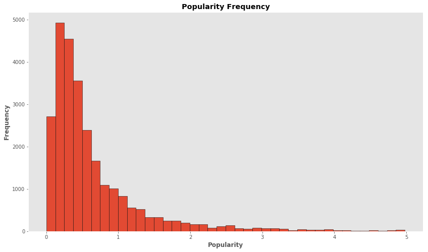

```python
# omit outliers
ommited_outlier = df.query('popularity<popularity.quantile(0.99)')
ax = ommited_outlier.popularity
#Begin plot
ax.plot(kind='hist',
        grid=False,
        bins=40,
        edgecolor="black",
        figsize=(14,8))
#Add x label and format it
plt.xlabel('popularity'.title(),weight="bold")
#Add y label and format it
plt.ylabel('Frequency'.title(),weight="bold")
#Add a title label and format it
plt.title('Popularity Frequency',weight="bold");
```

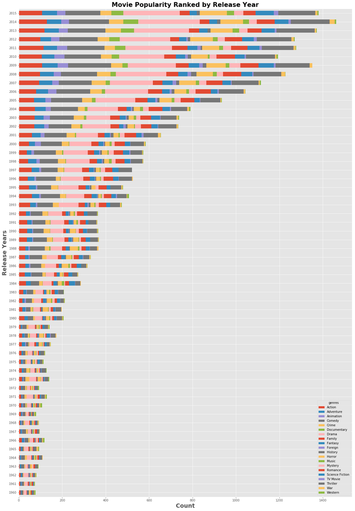

```python
# Assign to a variable genre_release_year a grouped count of release years and genres
# indexed by popularity
genre_release_year = df.groupby(['release_year','genres']).count()['popularity']\
.unstack()
#Begin plot
genre_release_year.plot(kind='barh',stacked=True,figsize=(20,30))
#Add y label and format it
plt.ylabel('Release Years',fontsize=19,weight="bold")
#Add x label and format it
plt.xlabel('Count',fontsize=19,weight="bold")
# Include a style to enhance our plot
plt.style.use('ggplot')
#Add a title label and format it
plt.title('Movie Popularity Ranked by Release Year',fontsize=21,weight="bold");
```

### Discovery

> From the visuals, it is clear that in the most present years (2010-2015), Drama, Comedy and thriller movies have been popular. However, movies from the drama genre appear to be the most popular.

### Research Question 2 : Which genres is most popular ?

```python
# Print out Distinct genres
genres = df.genres.unique()
print("{}".format(genres))
```

```
['Action' 'Adventure' 'Science Fiction' 'Thriller' 'Fantasy' 'Crime'
 'Western' 'Drama' 'Family' 'Animation' 'Comedy' 'Mystery' 'Romance' 'War'
 'History' 'Music' 'Horror' 'Documentary' 'TV Movie' 'Foreign']
```

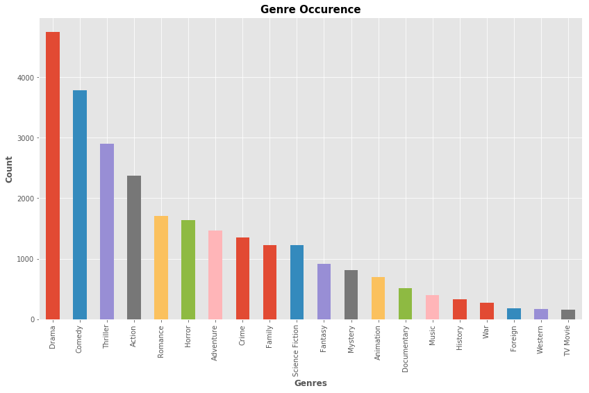

```python
# Fetch all the unique genre occurences
genres_unique = df.genres
# Begin plot
pd.Series(genres_unique).value_counts().plot(kind='bar',figsize=(14,8))
#Add y label and format it
plt.ylabel('Count',weight='bold')
#Add x label and format it
plt.xlabel('Genres',weight='bold')
#Add a title label and format it
plt.title('Genre Occurence',weight='bold',fontsize=15);
```

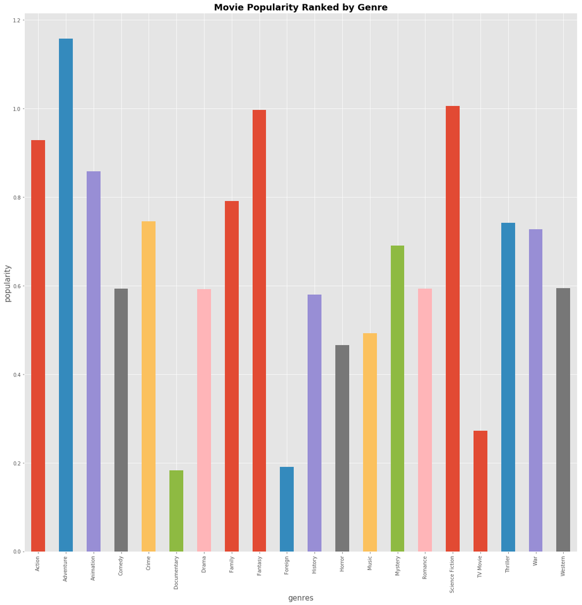

```python
# assign to a variable genre_popularity the genres mean indexed by popularity mean
genre_popularity = df.groupby('genres')['popularity'].mean()
#Begin plot
genre_popularity.plot(kind='bar',figsize=(20,20))
#Add x label and format it
plt.xlabel('genres',fontsize=15)
#Add y label and format it
plt.ylabel('popularity',fontsize=15)
#Add a title label and format it
plt.title('Movie Popularity Ranked by Genre',fontsize=18,weight="bold");
```

### Research Question 3: What kinds of properties are associated with movies that have high revenues ?

```python
sorted_descending = df.sort_values(by = 'revenue',ascending=False).iloc[:21]
# sorted_descending
```

[figure not shown]

```python
# omit outliers
ommited_outlier = df.query('revenue<revenue.quantile(0.99)')
ax = ommited_outlier.popularity
#Begin plot
ax.plot(kind='hist',
        grid=False,
        bins=40,
        edgecolor="black",
        figsize=(14,8))
# Add x label and format it
plt.xlabel('Revenue'.title(),weight="bold")
# Add y label and format it
plt.ylabel('Frequency'.title(),weight="bold")
# Add a title label and format it
plt.title('Revenue Frequency',weight="bold");
```

```python
# Define a function called visualPlot that takes 3 parameters
def visualPlot(df,colNameVar,title):
    '''
    This function reduces the need for code repetition by enabling me to call it anytime
    I need to plot a visual by just calling the function and passing an argument to it,
    for this case which is the column name.
    '''
    #Begin plot
    sorted_descending.groupby(colNameVar).size().plot(kind='barh',figsize=(14,8),width=0.8);
    # add a title to the plot
    plt.title(title.title(),fontsize=10,weight="bold")
    # add x label and format it
    plt.xlabel('Frequency'.title(),fontsize=10,weight="bold")
    # add y label and format it
    plt.ylabel(colNameVar.title(),fontsize=10,weight="bold")
```

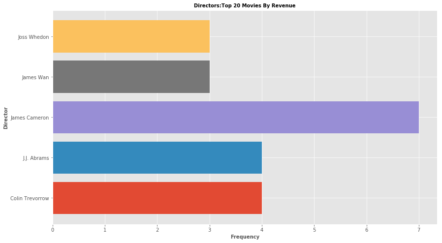

```python
# call the function to plot a visual and pass to it 3 parameters
visualPlot(df,'director',"Directors:Top 20 Movies by Revenue")
```

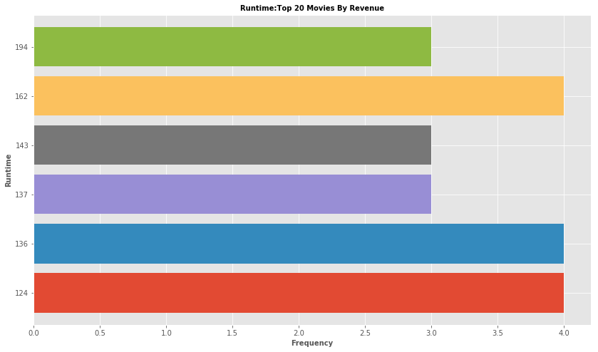

```python
# call the function to plot a visual and pass to it 3 parameters
visualPlot(df,'runtime',"Runtime:Top 20 Movies by Revenue")
```

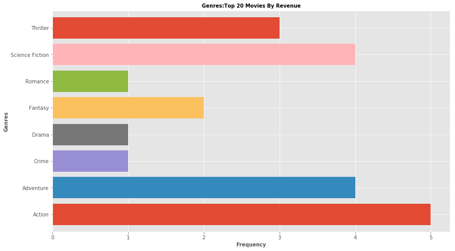

```python
# call the function to plot a visual and pass to it 3 parameters
visualPlot(df,'genres',"Genres:Top 20 Movies by Revenue")
```

### Discovery

```python
from subprocess import call
call(['python', '-m', 'nbconvert', 'Investigate_a_Dataset.ipynb'])
```

```
0
```